# Math 490 HW #10

Maxwell Levin

February 20, 2018

## Question 1.

#### Let $\small{I}$ be the area of the intersection of the unit circle centered at $\small{(0,0)}$ and the unit circle centered at $\small{(1,0)}$ inside the unit square. Consider computing $\small{I}$ using Monte Carlo methods.

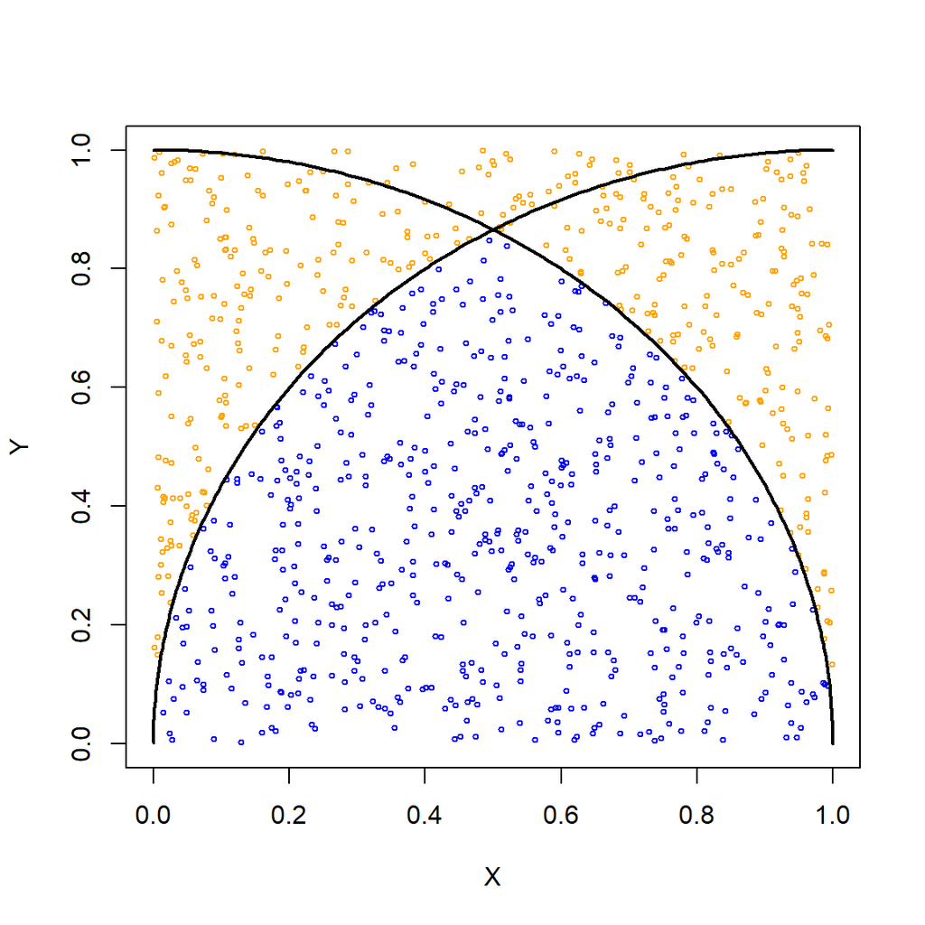

#### a. Construct a Monte Carlo estimator $\small{Z_N^{MC} = Z_N^{MC}(X_1, X_2, \dots, X_N)}$ with sample size $\small{N}$ for estimating $\small{I}$.

Our Monte Carlo estimator for $\small{I}$ is given by

$$Z_N^{MC} = \frac{\phi(x_1, y_1) + \phi(x_2, y_2) + \dots + \phi(x_N, y_N)}{N},$$

where we define $\small{\phi(x)}$ by

$$\phi(x, y) = \left\{
\begin{array}{ll}
1 & \text{if } 0 \leq x^2 + y^2 \leq 1 \text{ and } 0 \leq (x - 1)^2 + y^2 \leq 1; \\
0 & \text{otherwise.} \\
\end{array}
\right.$$

#### b. If sample size $\small{N = 100}$, what is the mean and the standard deviation of the Monte Carlo estimator constructed in part (a)?

With a little bit of math we find that

$$E(Z_{100}^{MC}) = I \approx 0.614.$$

We know from class that the standard deviation, $\small{\sigma}$, of a Monte Carlo estimator with a sample size of 1 is given by

$$SD(Z_1^{MC}) = \sqrt{I(1-I)} \approx 0.487.$$

The standard deviation of $\small{Z_{100}^{MC}}$ is given by

$$SD(Z_{100}^{MC}) = \frac{1}{10}SD(Z_1^{MC}) \approx 0.0487.$$

#### c. With sample size $\small{N = 100}$, use R to simulate 1024 Monte Carlo estimates of $\small{I}$. Make a histogram of those 1024 Monte Carlo estimates, and report the mean and the standard deviation of those 1024 estimates.

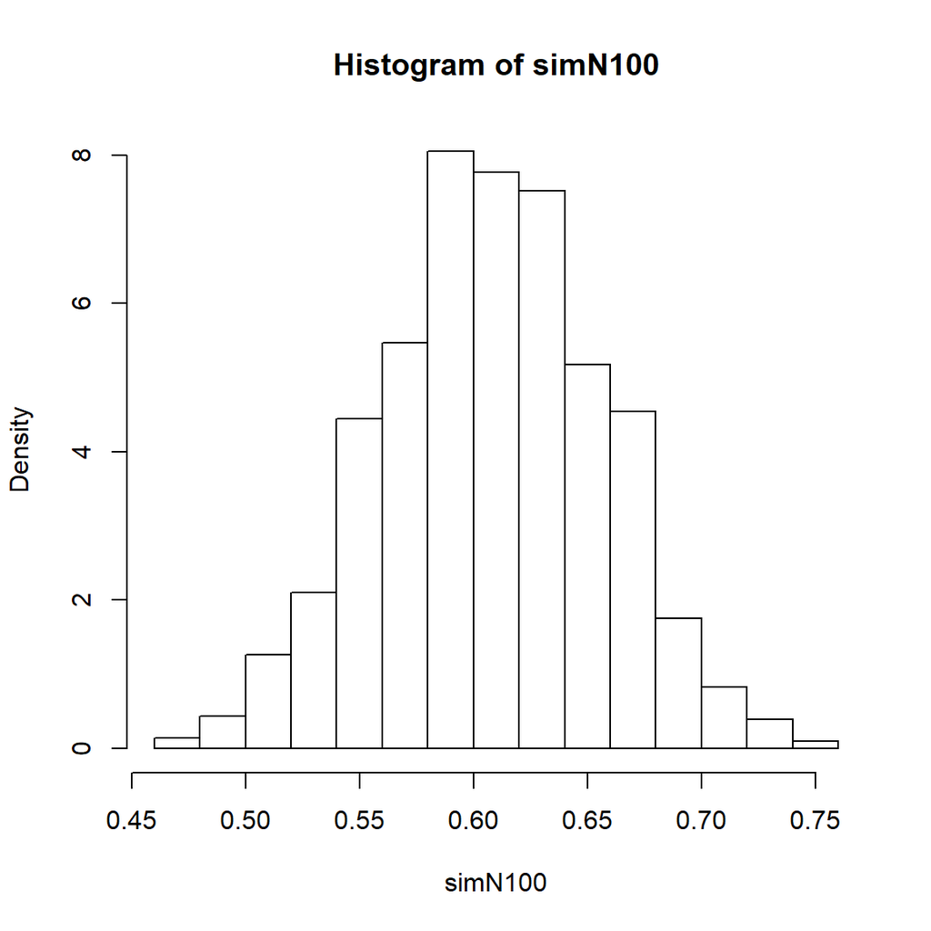

```r
areasMC = function(sam, rep) {
  obs = numeric(rep)
  for (i in 0:rep-1) {
    hits = 0
    for (j in 1:sam) {
      x = runif(1)
      y = runif(1)
      if ( x^2 + y^2 <= 1 & (x-1)^2 + y^2 <= 1 ) {
        hits = hits + 1
      }
    }
    obs[i] = hits/sam
  }
  obs
}

simN100 = areasMC(100, 1024)
hist(simN100, breaks=seq(min(simN100), max(simN100) + 0.01, 0.02), prob=T)
```

The mean of our simulation is

```
[1] 0.612666
```

The standard deviation of our simulation is

```
[1] 0.04831088
```

We notice that our calculations here are not far off from our calculations in part (b).

#### d. If the sample size $\small{N = 100}$, how likely is our Monte Carlo estimate $\small{Z_{100}^{MC}}$ to yield an estimate of $\small{I}$ within an error of $\small{\pm 0.03}$? Use R to simulate this probabilty.

We run the following code to determine this probability:

```r
getPr = function(sam, rep, err=0.03) {
  I = 0.614
  count = 0
  for (i in 1:rep) {
    hits = 0
    for (j in 1:sam) {
      x = runif(1)
      y = runif(1)
      if ( x^2 + y^2 <= 1 & (x-1)^2 + y^2 <= 1 ) {
        hits = hits + 1
      }
    }
    zbar = hits/sam
    if (I - 0.03 <= zbar & zbar <= I + 0.03){
      count = count + 1
    }
  }
  count/rep
}

prN100 = getPr(100, 1024)
prN100
```

```
[1] 0.4707031
```

Thus we see that we have around a 50% chance of getting within $\small{\pm 0.03}$ of $\small{I}$.

#### e. How large should $\small{N}$ be such that our Monte Carlo estimate $\small{Z_N^{MC}}$ would yield an estimate of $\small{I}$ within an error of $\small{\pm 0.03}$ with probability $\small{95\%}$?

We know from class that we should pick $\small{N}$ such that

$$N = \left(\frac{1.96\sigma}{0.03}\right)^2 \approx 1012.$$

We can verify this by running the code we wrote in part (d) with a sample size of 1012 and 1024 repitions:

```
[1] 0.9492188
```

Success!